# hw8

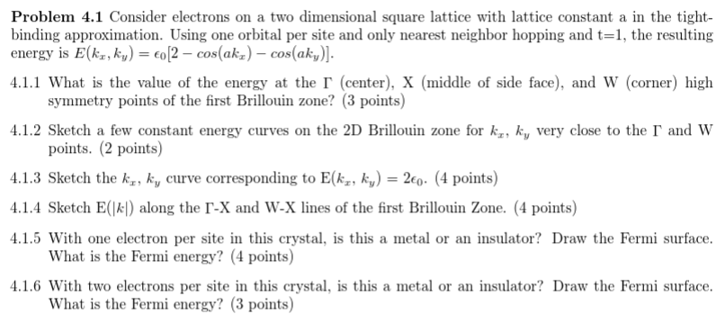

Before we get started on this problem, let's have a look at what this potential looks like for the square lattice.

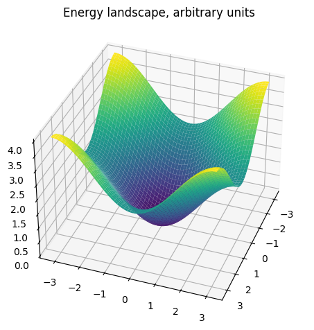

```python
import numpy as np
from numpy import cos, pi

import matplotlib.pyplot as plt

e0 = 1
a = 1
params = [e0, a]

x = np.linspace(-pi/a, pi/a, 1000)
y = np.linspace(-pi/a, pi/a, 1000)

kx, ky = np.meshgrid(x, y)

def tight_binding(kx, ky, params):
    e0, a = params
    return e0*(2-cos(a*kx)-cos(a*ky))

energy = tight_binding(kx, ky, params)

ax = plt.figure().add_subplot(111, projection='3d')
ax.plot_surface(kx, ky, energy, cmap='viridis')
ax.view_init(35, 20)
plt.title('Energy landscape, arbitrary units')
plt.tight_layout()
```

It appears that for each brillion zone, it's easier to break through X than W. It is unclear to me if this represents the energy of the electron or the potential due to the atom, since an atom centered at $k_x,k_y = 0$ should have higher energy, not lower. This is reciprocal space, so larger $k$ means greater momentum

4.1.1

4.1.2 see plot below.

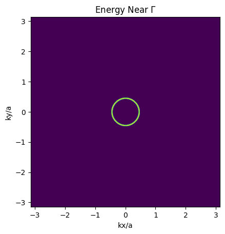

```python
def near_energy_val(energy, target, tol=0.01):
    return np.where(np.abs(energy - target) < tol, energy, 0)

energy_near_gamma = near_energy_val(energy, 0.1)

plt.imshow(energy_near_gamma, extent=((x/a).min(), (x/a).max(), (y/a).min(), (y/a).max()), origin='lower')
plt.xlabel('kx/a')
plt.ylabel('ky/a')
plt.title(r'Energy Near $\Gamma$')
plt.show()
```

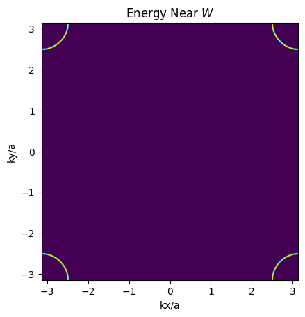

```python
energy_near_gamma = near_energy_val(energy, 4*e0*0.95)

plt.imshow(energy_near_gamma, extent=((x/a).min(), (x/a).max(), (y/a).min(), (y/a).max()), origin='lower')
plt.xlabel('kx/a')
plt.ylabel('ky/a')
plt.title(r'Energy Near $W$')
plt.show()
```

4.1.3 See plot below. This sketch can also be made by making a plot of the values (x,y) when $\cos(x) = -\cos(y)$

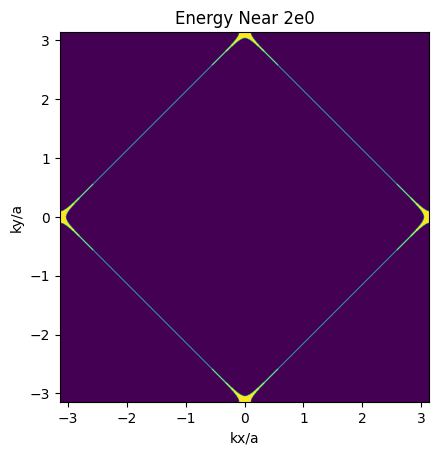

```python
energy_near_2e0 = near_energy_val(energy, 2*e0, tol=0.005)

plt.imshow(energy_near_2e0, extent=((x/a).min(), (x/a).max(), (y/a).min(), (y/a).max()), origin='lower')
plt.xlabel('kx/a')
plt.ylabel('ky/a')
plt.title('Energy Near 2e0')
plt.show()
```

4.1.4 See plots below. $E(|k|)$ along the $W-X$ line doesn't actually exist for $|k|<\pi/a$, so I plotted for $k_x$ instead.

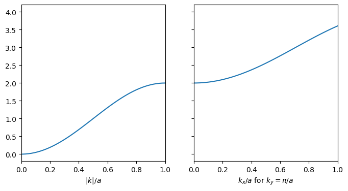

```python
kx = np.linspace(-pi/a, pi/a, 100)

G_X = tight_binding(kx, 0, params)
G_W = tight_binding(pi/a, kx, params)

fig, (ax1, ax2) = plt.subplots(1, 2, sharex=True, sharey=True)

ax1.plot(kx/pi, G_X)
ax1.set_xlabel(r'$|k|/a$')

ax1.set_xlim((0, 1))
ax2.plot(kx*2**(1/2)/pi, G_W)
ax2.set_xlabel(r'$k_x/a$ for $k_y=\pi/a$')
ax2.set_xlim((0, 1))

fig.set_figwidth(8)
fig.set_figheight(4)
```

4.1.5 The energy is $2\epsilon_0$. See the plot below. This is definitely a metal. Since two electrons are needed to fill each site, only half of the sites are filled. Any voltage can push electrons to fill sites above the usual Fermi energy, which can cause current flow. Thanks to the diamond shape that we get from $E=2\epsilon_0$, half the area is below the line and half is above.

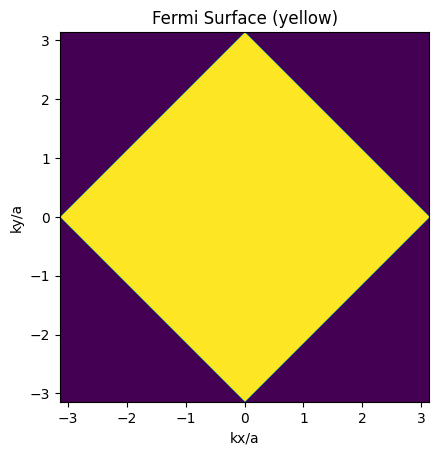

```python
tol = 0

fermi_surface = np.where(energy - 2*e0 < tol, 1, 0)

plt.imshow(fermi_surface, extent=(x.min(), x.max(), y.min(), y.max()), origin='lower')
plt.xlabel('kx/a')
plt.ylabel('ky/a')
plt.title('Fermi Surface (yellow)')
plt.show()
```

4.1.6 This is an insulator. Since there is one orbital for each atom, and two electrons for each atom, all orbitals have two electrons and are filled due to the Pauli exlusion princliple. Electrons cannot absorb energy, since they are 'quantized' and cannot move to another orbital without entirely escaping. No current can flow since electrons cannot move to new locations.

The plot of the fermi surface is just the whole cell